# Lessons from My (S)crappy Reproducibility Journey

Clement Lee (Newcastle University)

2024-09-04 (Wed)

# Me

- Lecturer at Newcastle University
- Teach how to:
  - use R
  - do statistics (using R)

[figure not shown]

- Local network co-lead of UK Reproducibility Network (UKRN)
- Organise activities on reproducibility & open research

[figure not shown]

# Teaching statistics

- First module for MSc Data Science
- Exploratory analysis of a simple data set in R
- Write report using R Markdown
- Use the Rmd to reproduce their report:
  - *Can it be generated with another machine?*
  - *Can it be generated with new data?*
  - *Are the results still valid with new data?*

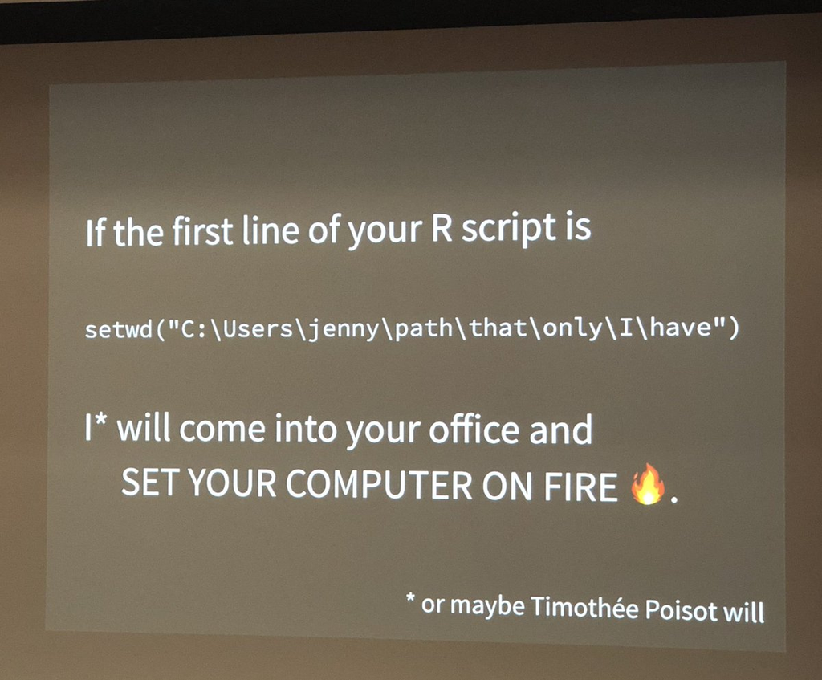

https://bit.ly/setwd

# Lesson

- Lots need to be taught
  - … alongside the “core” materials
  - even absolute vs relative paths
  - let alone packages e.g. ProjectTemplate, reprex
- It takes effort to reproduce
  - binder (https://mybinder.org) very useful

# First contact

- Lee and Wilkinson (2019)
  - https://doi.org/10.1080/01621459.2019.1585358
- An AE actually checked if the code runs and gives the reported results
- https://jasa-acs.github.io/repro-guide/

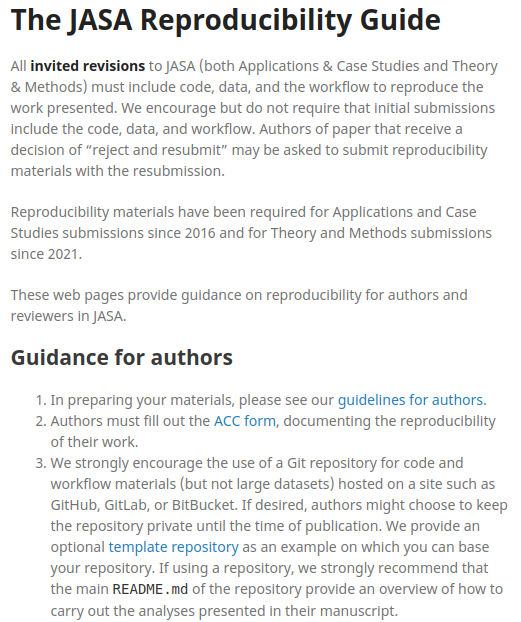

# Revisiting

- Can the results still be reproduced?
- Yes! Not perfect though
  - didn’t use packrat or renv
  - `dplyr::summarise_all()` is deprecated
- More importantly …

# Rookie mistake

- My actual code

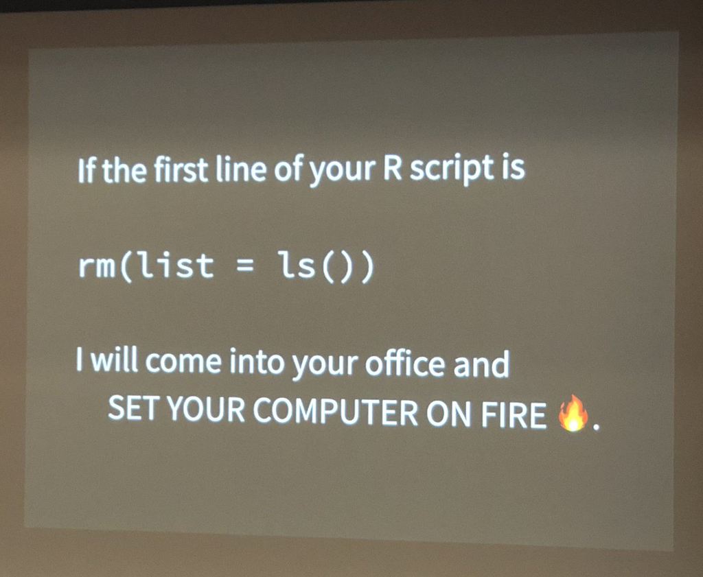

https://bit.ly/rm-list-ls

```r
## prelim
print(Sys.time())
remove(list = ls())
library(hybridProcess)
source("gots7_prelim.R")
source("initial_values_20170716_single.R")

## run
run_mcmc("20170716", 2468L, me_etas, N.gots7,
         t.gots7, b.gots7, f.gots7, a0.gots7,
         b0.gots7, p0.gots7, p01.gots7,
         p10.gots7, write = FALSE, l0.gots7,
         beta.gots7, kappa.gots7, lambda.gots7,
         phi.gots7, psi.gots7, tau.gots7,
         theta.gots7, s_beta.gots7, s_kappa.gots7,
         s_lambda.gots7, s_psi.gots7, s_theta.gots7,
         s_e_init.gots7, rebuild = TRUE)

## exit
remove(list = ls())
print(Sys.time())
```

# Lesson

- Nothing lasts forever
  - Keep up-to-date what’s new
  - Let package management tools take care of the past
- Future-proof your work
  - It helps others to reproduce your work …
  - … including **your future self**
  - README helps
- Adopt early
  - (Ask your PhD student / postdoc to) do it now
  - Doesn’t need to be perfect the first time
  - It will save you time in the future

# So far

- A lot skipped
  - Version control, documentation, package development, testing
  - Container briefly mentioned: binder, docker, etc.
- **Computational** reproducibility is only the beginning
  - Social sciences / medical statistics care about related issues
  - Reproducibility? Replicability?
- Do new data / experiments lead to the same conclusion?
  - Not identical $p$-values to what you’ve got (unlikely)
  - Same hypothesis supported / not-supported
- Does the methodology make sense?
  - Verified results aren’t necessarily good or useful
- Has the method been changed to fit the data?
  - Garden of the forking paths

# Open Research & UKRN

- A national consortium promoting best practice in Open Research
  - https://www.ukrn.org
- Institutions form their own local network
  - Colleagues & research students within Newcastle University
- ReproducibiliTea journal club
  - Sharing good practices from papers or their own work
- Drop-in sessions
  - Support colleagues with open research practices
- Join/create your local network if you have not already

[figure not shown]

# Thank you!

- Website: https://clement-lee.github.io
- Slides: https://bit.ly/rss-2024

[figure not shown]